# Exploration of loan data

# Structure of dataset

```r
str(pf)
```

```
## 'data.frame':    113937 obs. of  81 variables:
##  $ ListingKey                         : Factor w/ 113066 levels "00003546482094282EF90E5",..: 7180 7193 6647 6669 6686 6689 6699 6706 6687 6687 ...
##  $ ListingNumber                      : int  193129 1209647 81716 658116 909464 1074836 750899 768193 1023355 1023355 ...
##  $ ListingCreationDate                : Factor w/ 113064 levels "2005-11-09 20:44:28.847000000",..: 14184 111894 6429 64760 85967 100310 72556 74019 97834 97834 ...
##  $ CreditGrade                        : Factor w/ 9 levels "","A","AA","B",..: 5 1 8 1 1 1 1 1 1 1 ...
##  $ Term                               : int  36 36 36 36 36 60 36 36 36 36 ...
##  $ LoanStatus                         : Factor w/ 12 levels "Cancelled","Chargedoff",..: 3 4 3 4 4 4 4 4 4 4 ...
##  $ ClosedDate                         : Factor w/ 2803 levels "","2005-11-25 00:00:00",..: 1138 1 1263 1 1 1 1 1 1 1 ...
##  $ BorrowerAPR                        : num  0.165 0.12 0.283 0.125 0.246 ...
##  $ BorrowerRate                       : num  0.158 0.092 0.275 0.0974 0.2085 ...
##  $ LenderYield                        : num  0.138 0.082 0.24 0.0874 0.1985 ...
##  $ EstimatedEffectiveYield            : num  NA 0.0796 NA 0.0849 0.1832 ...
##  $ EstimatedLoss                      : num  NA 0.0249 NA 0.0249 0.0925 ...
##  $ EstimatedReturn                    : num  NA 0.0547 NA 0.06 0.0907 ...
##  $ ProsperRating..numeric.            : int  NA 6 NA 6 3 5 2 4 7 7 ...
```

[output cut: 67 more lines]

- Dataset consists of 81 variables, with 113,937 observations.

# Univariate exploration

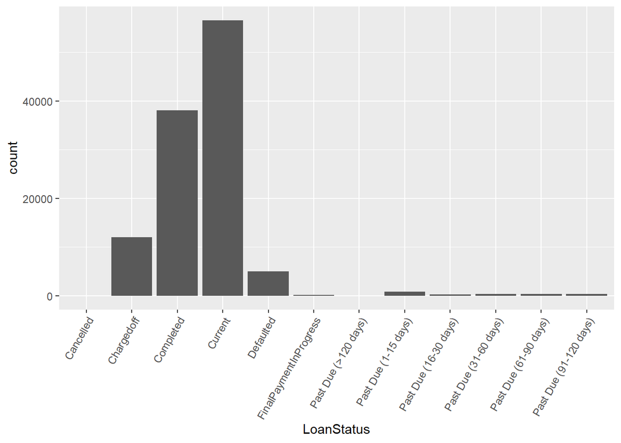

```r
ggplot(aes(x=LoanStatus, y=..count..), data=pf) +
  geom_bar() +theme(axis.text.x = element_text(angle = 60, hjust = 1))
```

```r
levels(pf$LoanStatus)
```

```
##  [1] "Cancelled"              "Chargedoff"
##  [3] "Completed"              "Current"
##  [5] "Defaulted"              "FinalPaymentInProgress"
##  [7] "Past Due (>120 days)"   "Past Due (1-15 days)"
##  [9] "Past Due (16-30 days)"  "Past Due (31-60 days)"
## [11] "Past Due (61-90 days)"  "Past Due (91-120 days)"
```

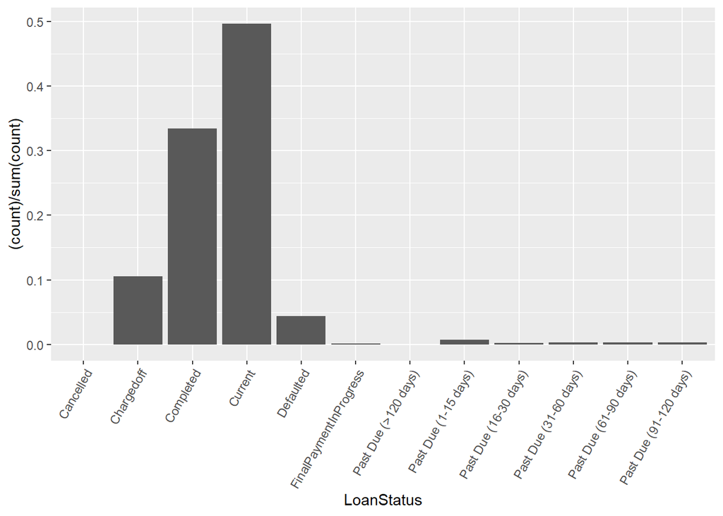

```r
ggplot(data=pf, aes(x=LoanStatus))+
  geom_bar(aes(y = (..count..)/sum(..count..)))+
  theme(axis.text.x = element_text(angle = 60, hjust = 1))
```

- Most of the loans are in current state(50 %), and 34 % of loans has completed.
- One important thing to be noted, 10 % of loans are charged-off and of high risk to lenders.

```r
unique(pf$Term)
```

```
## [1] 36 60 12
```

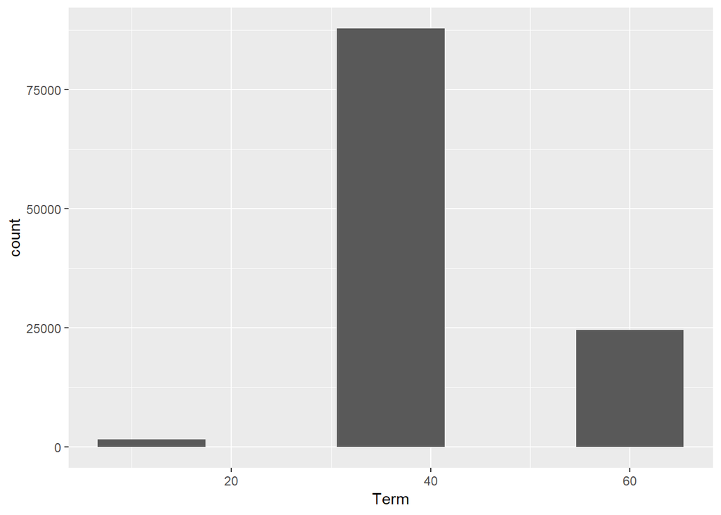

```r
ggplot(aes(x=Term),data=pf)+
  geom_bar()
```

- There are 12, 36 and 60 months loan as choices, and most of the loan is 3-year long.

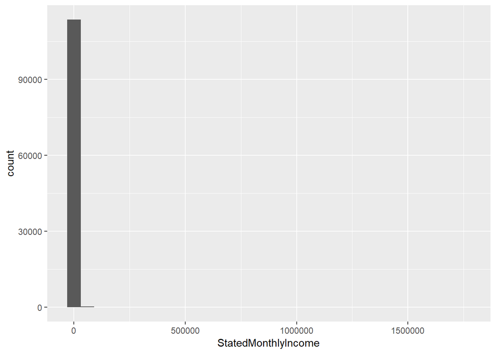

```r
 ggplot(aes(x=StatedMonthlyIncome), data=pf) +
  geom_histogram()
```

* Some high income makes the State monthly income histogram has a long tail.

```r
summary(pf$BorrowerRate)
```

```
##    Min. 1st Qu.  Median    Mean 3rd Qu.    Max.
##  0.0000  0.1340  0.1840  0.1928  0.2500  0.4975
```

```r
summary(pf$BorrowerAPR)
```

```
##    Min. 1st Qu.  Median    Mean 3rd Qu.    Max.    NA's
## 0.00653 0.15629 0.20976 0.21883 0.28381 0.51229      25
```

```r
summary(pf$StatedMonthlyIncome)
```

```
##    Min. 1st Qu.  Median    Mean 3rd Qu.    Max.
##       0    3200    4667    5608    6825 1750003
```

```r
length(which(pf$StatedMonthlyIncome>10000))
```

```
## [1] 9780
```

```r
median(pf$StatedMonthlyIncome)
```

```
## [1] 4666.667
```

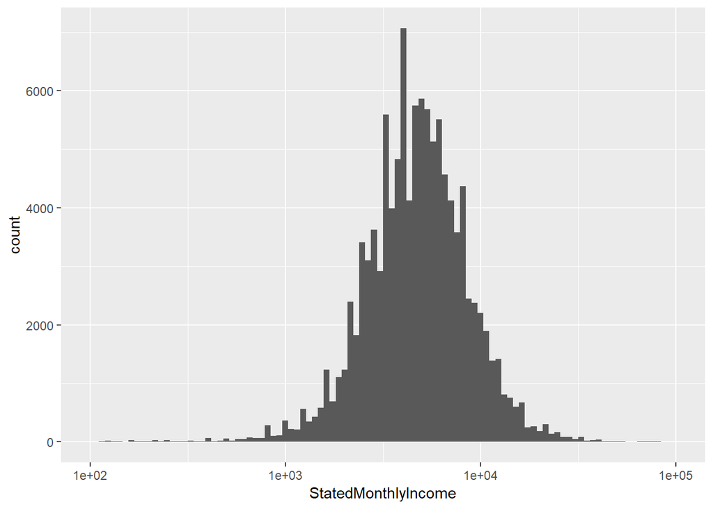

```r
ggplot(aes(x=StatedMonthlyIncome), data=pf) +
  geom_histogram(bins=100)+ scale_x_continuous(trans='log10',limits = c(100, 100000))
```

- After transforming the x scale to log10 and focus on the center, it now close to a normal distribution with a median income of 4667.
- Does people with higher income less likely to past due?

# Univariate Analysis

## Structure of data

There are 81 variables and 113,937 observations in the dataset.

## Main observations

- Most borrowers have an income between 3200 and 6825 per month, with a median income of 4667 dollar.
- Most loan has a term of 36 months.
- 10 % of loans are charged-off, which should be concerned.

## Main main feature of interest

The main feature interested is the Loan status data, which consist of “Cancelled”, “Chargedoff”, “Completed”,“Current”,“Defaulted”, “FinalPaymentInProgress” “Past Due (>120 days)”,“Past Due (1-15 days)” ,“Past Due (16-30 days)”, “Past Due (31-60 days)”,“Past Due (61-90 days)”,“Past Due (91-120 days)”. I am intested in if other variables can predict the high risk loans such as charged off and past due.

## Of the features you investigated, were there any unusual distributions?

The stated income has a long tail and right skewed due to some large values, a log10 transformation resulted in a normal distribution.